# Regression Project

Thomas Townsley, John Carr, Matthew Lewis

December 7th, 2018

## Abstract

Our goal with this project was to build a model that would predict the price of a home in the Washington D.C. area. We used a dataset that included 2,000 observations of other homes in the area with pertinent data to power the model. Our final model had an R2 of 0.75, which we beleive to be strong. When we run the predictor three out of the five lines we removed from the dataset are predicted acurately. Our conclusion is that our model would allow us to achieve the business need we set out to solve.

```r
# 1. Abstract
```

## Introduction

With our model, if we had pertinent data on a home in D.C., but not the price, we will be able to predict what the price should be. Also, this model would be useful in determining what the price of a home in DC should cost even if there is a price already associated with it. For example, if one were to be in the market for such a home, this model would help the buyer or seller understand what would be a reasonable final price. This would inform the amount a buyer could/should offer, or the price a seller could justifiably list the home at. Data such as land area of the home, number of rooms, year built, etc. will power the predictive algorithym. As we began the discovery of this project, we anticipated that variables such as land area and number of rooms would be the most significant.

```r
# 2. Introduction
```

## Overview of the dataset

Our dataset is titled D.C. Residential Properties and was acquired on kaggle.com. This dataset shows real property information, including most recent sales prices as of July 2018, for properties located in Washington, D.C. There are a number of variables that we beleive would be useful to us in achieving our goal, with “Condition” being the main conditional variable we use. We eliminated some variables that we decided would not be relevant or useful immediately.

One way we manipulated the original dataset is by transforming the SALEDATE variable into separate variables for SALEYEAR, SALEMONTH and SALEDAY. We did this because we found little significance to SALEDATE as each was unique and spreadout, and thought there might be more significance in using individual parts of the dates at higher levels. We kept the original SALEDATE column in the dataset, as well.

Description of variables: BATHRM (numeric): Number of full bathrooms HF_BATHRM (numeric): Number of half bathrooms (no bathtub or shower) ROOMS (numeric): Total number of rooms BEDRM (numeric): Number of bedrooms AYB (numeric): The earliest time the main portion of the building was built YR_RMDL (numeric): Year structure was remodeled STORIES (numeric): Number of stories in primary dwelling SALEDATE (date): Date of most recent sale SALEMONTH (numeric): Column we created for the calendar month of the most recent sale SALEDAY (numeric): Column we created for the calendar day of the most recent sale SALEYEAR (numeric): Column we created for the calendar year of the most recent sale GBA (numeric): Gross building area in square feet CNDTN (factor): Condition LANDAREA (numeric): Land area of property in square feet PRICE (numeric): Price of most recent sale

```r
# 3. Overview of the dataset
```

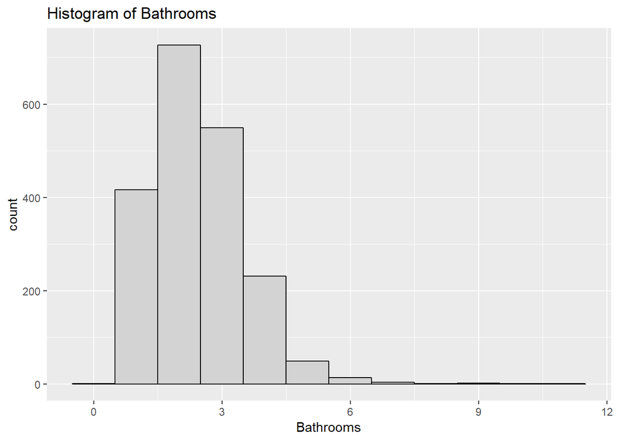

```r
# 4. Exploratory analysis

houses <- read.csv("DC_properties_clean.csv")

excl_rows <- houses[sample(nrow(houses), 5), ] # Exclude Random Rows
houses <- setdiff(houses, excl_rows)

houses$CNDTN <- factor(houses$CNDTN, order = TRUE, levels = c("Fair", "Average", "Good", "Very Good", "Excellent"))

fit <- lm(data = houses, PRICE ~ BATHRM + HF_BATHRM  + ROOMS + BEDRM + AYB + YR_RMDL + STORIES + SALEMONTH + SALEDAY + SALEYEAR + GBA + CNDTN + LANDAREA)



#Histograms to examine distribution of each variable

ggplot(houses, aes(x = BATHRM))+
  geom_histogram(color="black", fill="light gray", binwidth = 1)+
  labs(x="Bathrooms", title="Histogram of Bathrooms")
```

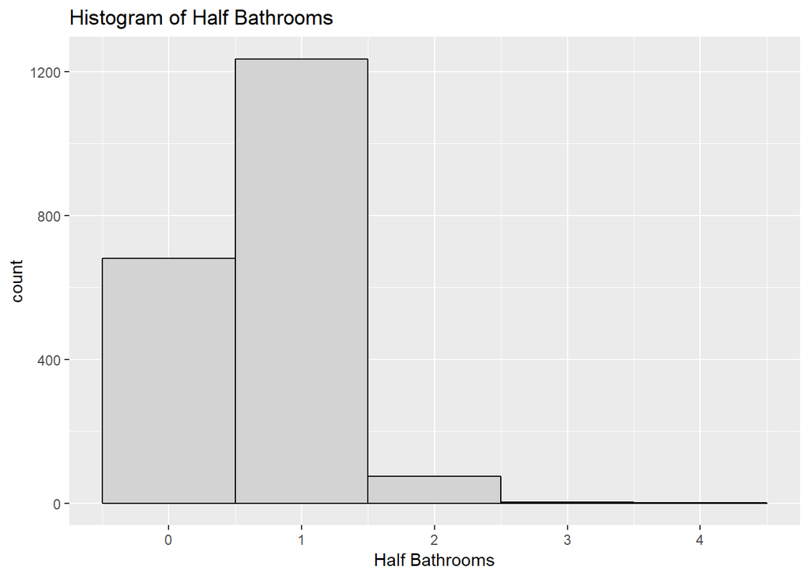

```r
ggplot(houses, aes(x = HF_BATHRM))+
  geom_histogram(color="black", fill="light gray", binwidth = 1)+
  labs(x="Half Bathrooms", title="Histogram of Half Bathrooms")
```

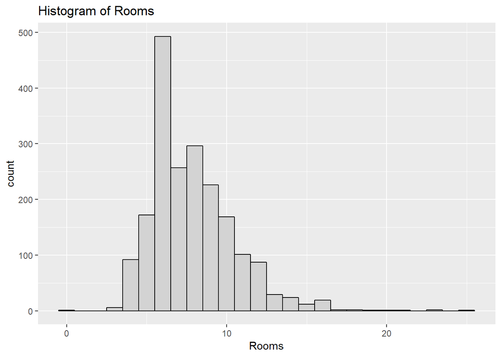

```r
ggplot(houses, aes(x = ROOMS))+
  geom_histogram(color="black", fill="light gray", binwidth = 1)+
  labs(x="Rooms", title="Histogram of Rooms")
```

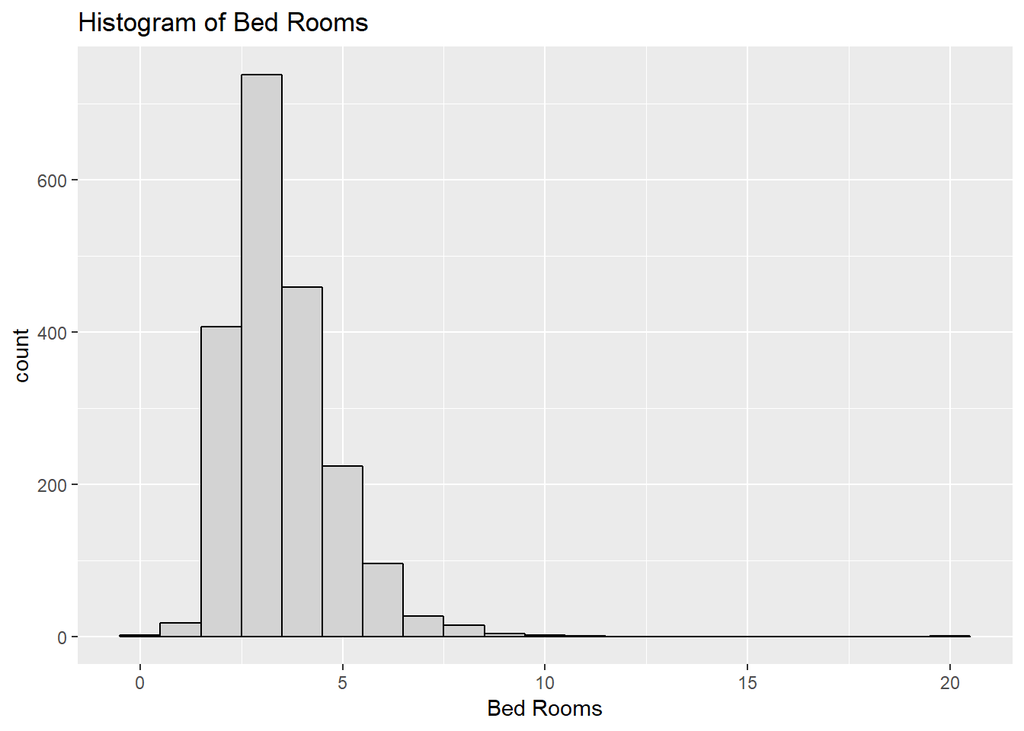

```r
ggplot(houses, aes(x = BEDRM))+
  geom_histogram(color="black", fill="light gray", binwidth = 1)+
  labs(x="Bed Rooms", title="Histogram of Bed Rooms")
```

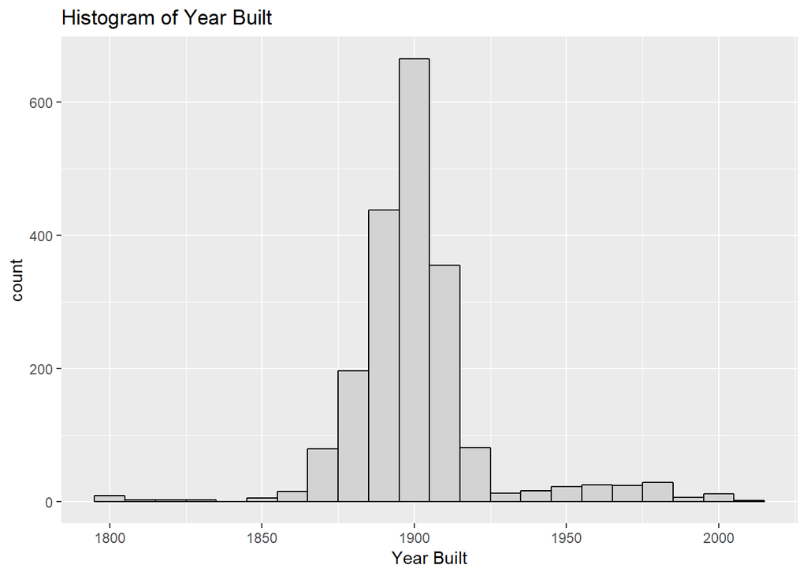

```r
ggplot(houses, aes(x = AYB))+
  geom_histogram(color="black", fill="light gray", binwidth = 10)+
  labs(x="Year Built", title="Histogram of Year Built")
```

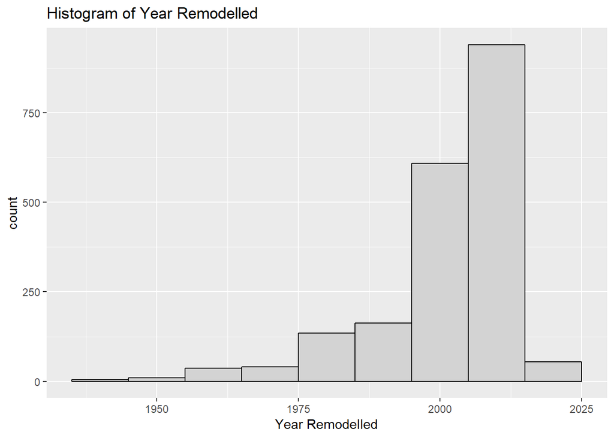

```r
ggplot(houses, aes(x = YR_RMDL))+
  geom_histogram(color="black", fill="light gray", binwidth = 10)+
  labs(x="Year Remodelled", title="Histogram of Year Remodelled")
```

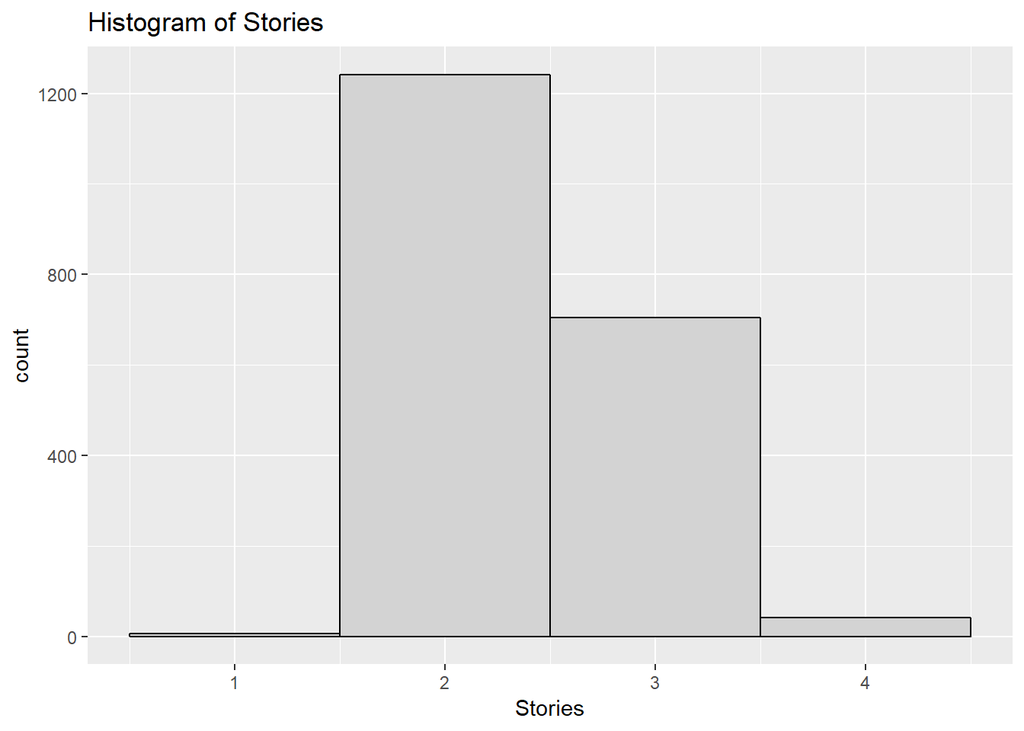

```r
ggplot(houses, aes(x = STORIES))+
  geom_histogram(color="black", fill="light gray", binwidth = 1)+
  labs(x="Stories", title="Histogram of Stories")
```

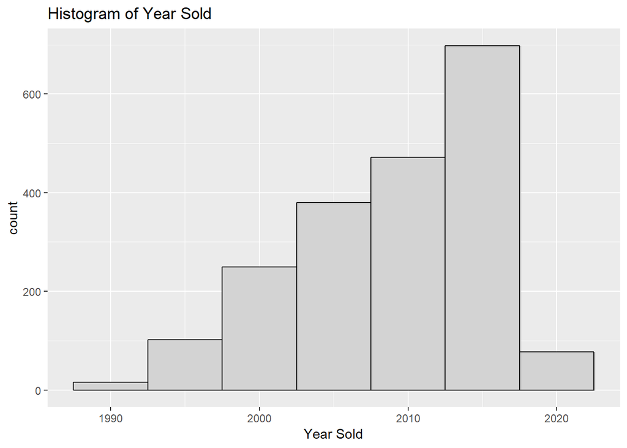

```r
ggplot(houses, aes(x = SALEYEAR))+
  geom_histogram(color="black", fill="light gray", binwidth = 5)+
  labs(x="Year Sold", title="Histogram of Year Sold")
```

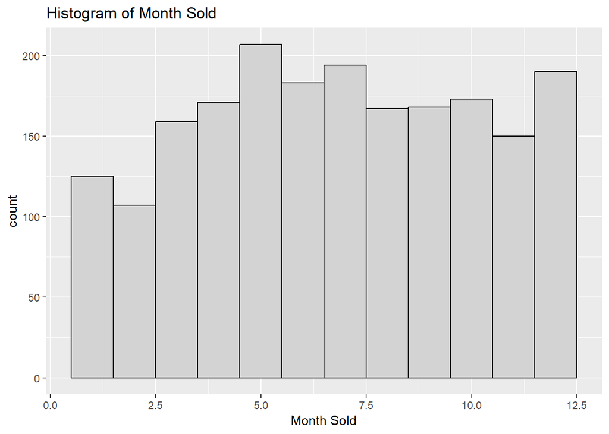

```r
ggplot(houses, aes(x = SALEMONTH))+
  geom_histogram(color="black", fill="light gray", binwidth = 1)+
  labs(x="Month Sold", title="Histogram of Month Sold")
```

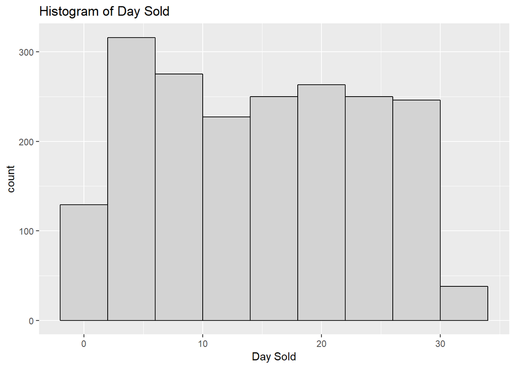

```r
ggplot(houses, aes(x = SALEDAY))+
  geom_histogram(color="black", fill="light gray", binwidth = 4)+
  labs(x="Day Sold", title="Histogram of Day Sold")
```

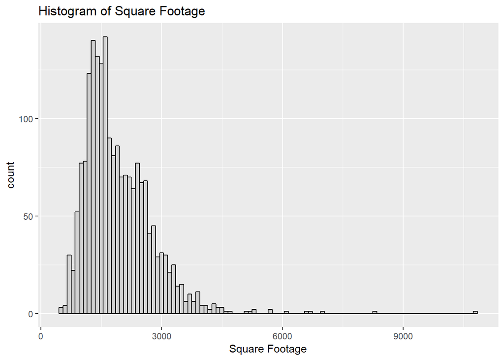

```r
ggplot(houses, aes(x = GBA))+
  geom_histogram(color="black", fill="light gray", binwidth = 100)+
  labs(x="Square Footage", title="Histogram of Square Footage")
```

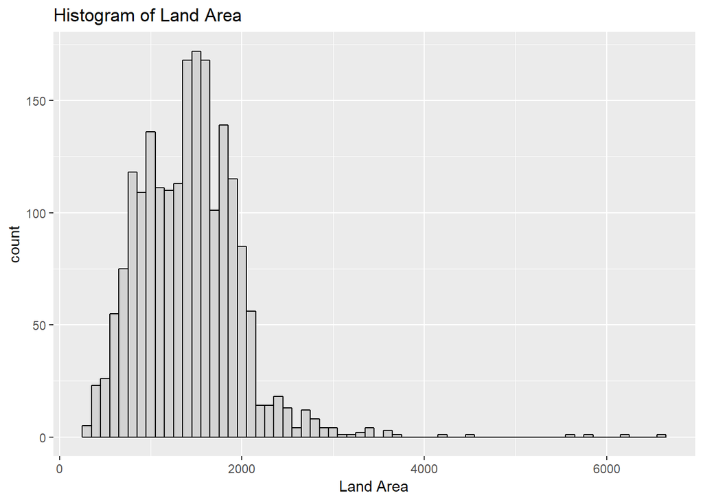

```r
ggplot(houses, aes(x = LANDAREA))+
  geom_histogram(color="black", fill="light gray", binwidth = 100)+
  labs(x="Land Area", title="Histogram of Land Area")
```

[figure not shown]

```r
ggplot(houses, aes(x = CNDTN))+
  geom_bar(color="black", fill="light gray")+
  labs(x="Land Area", title="Bar Plot of Land Area")
```

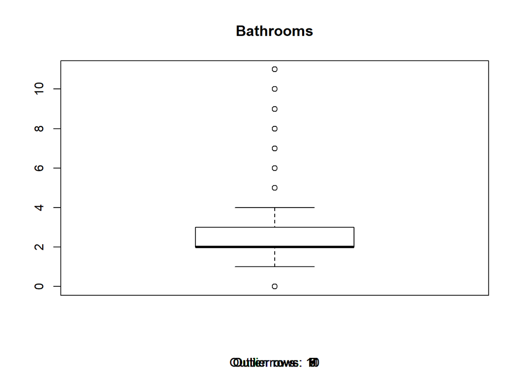

```r
# Boxplots to identify outliers

boxplot(houses$BATHRM, main="Bathrooms", sub=paste("Outlier rows: ", boxplot.stats(houses$BATHRM)$out))
```

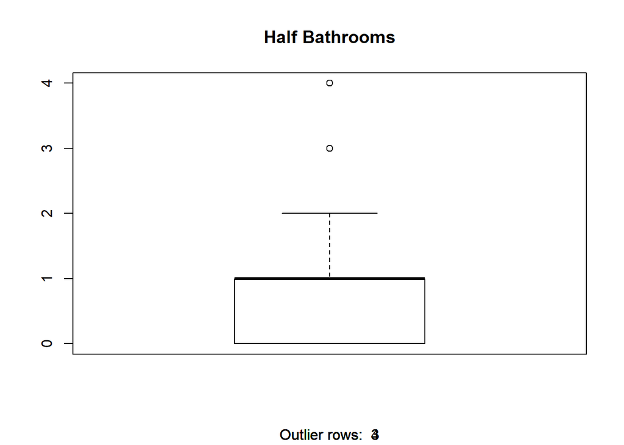

```r
boxplot(houses$HF_BATHRM, main="Half Bathrooms", sub=paste("Outlier rows: ", boxplot.stats(houses$HF_BATHRM)$out))
```

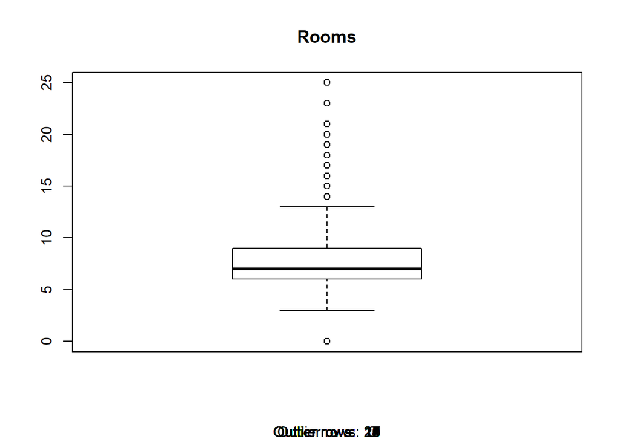

```r
boxplot(houses$ROOMS, main="Rooms", sub=paste("Outlier rows: ", boxplot.stats(houses$ROOMS)$out))
```

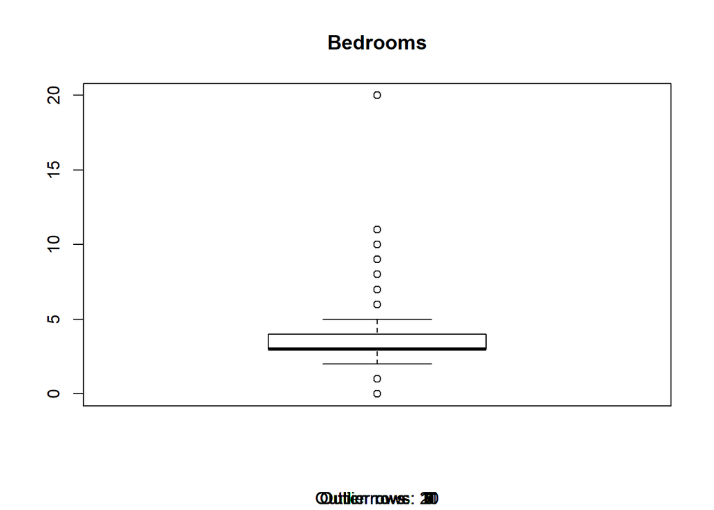

```r
boxplot(houses$BEDRM, main="Bedrooms", sub=paste("Outlier rows: ", boxplot.stats(houses$BEDRM)$out))
```

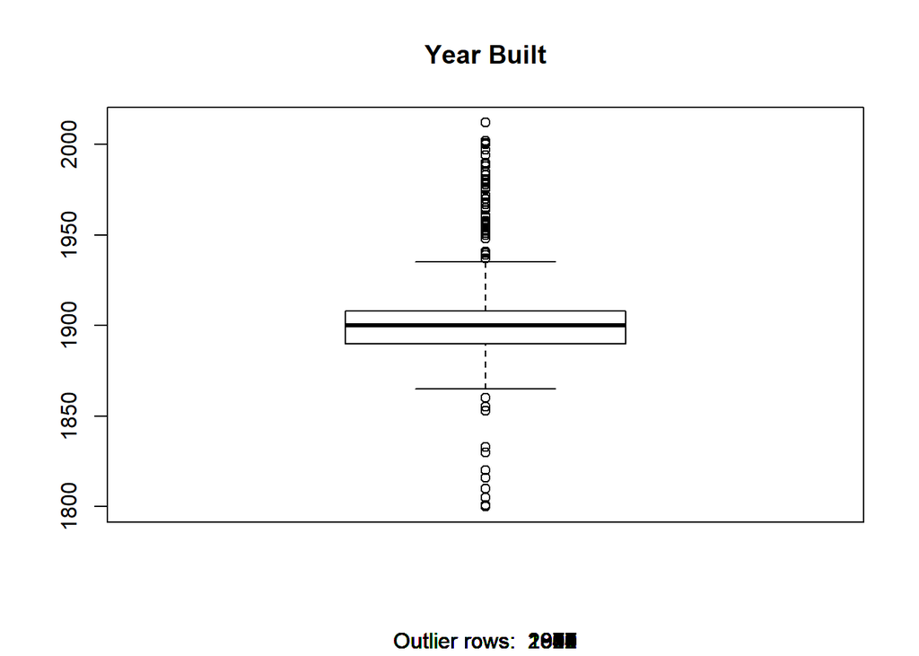

```r
boxplot(houses$AYB, main="Year Built", sub=paste("Outlier rows: ", boxplot.stats(houses$AYB)$out))
```

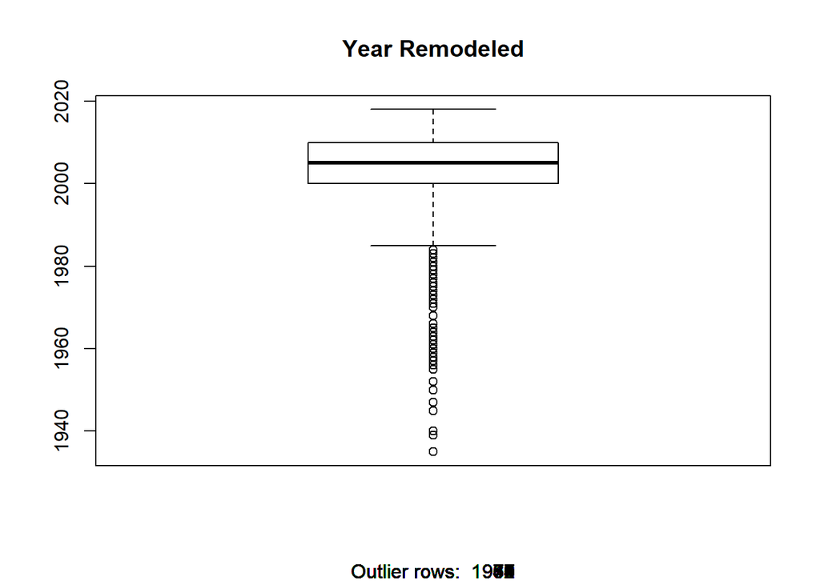

```r
boxplot(houses$YR_RMDL, main="Year Remodeled", sub=paste("Outlier rows: ", boxplot.stats(houses$YR_RMDL)$out))
```

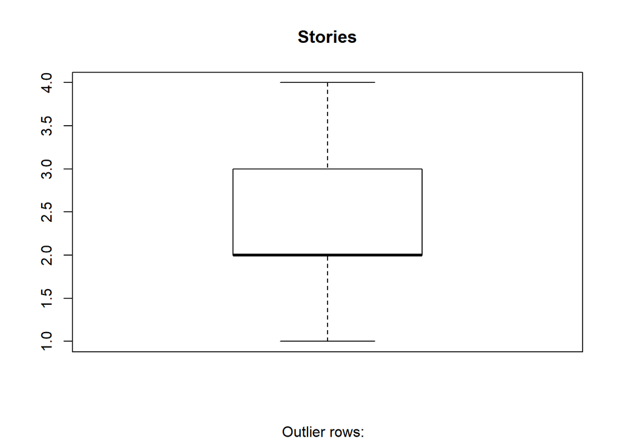

```r
boxplot(houses$STORIES, main="Stories", sub=paste("Outlier rows: ", boxplot.stats(houses$STORIES)$out))
```

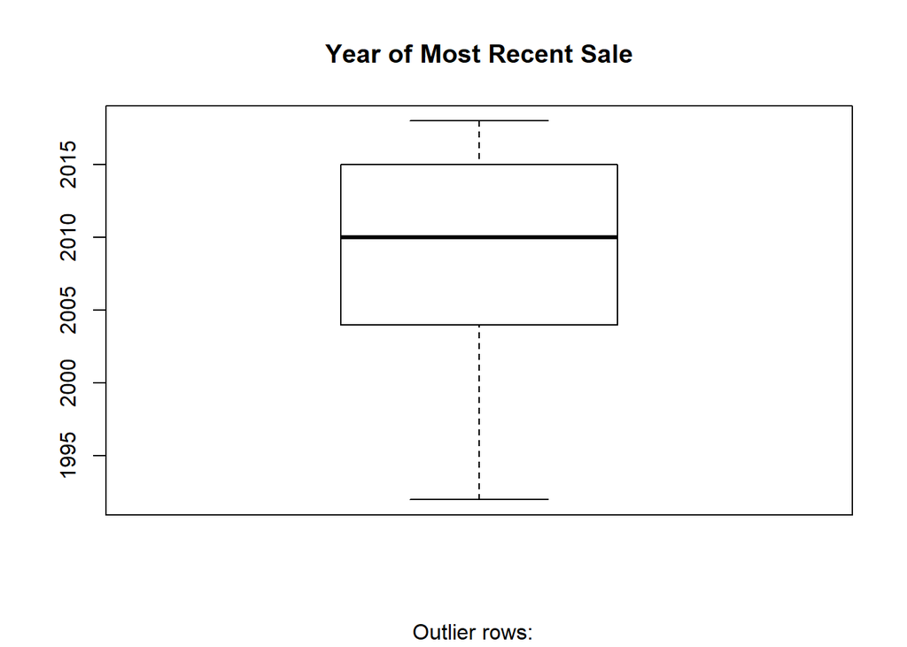

```r
boxplot(houses$SALEYEAR, main="Year of Most Recent Sale", sub=paste("Outlier rows: ", boxplot.stats(houses$SALEYEAR)$out))
```

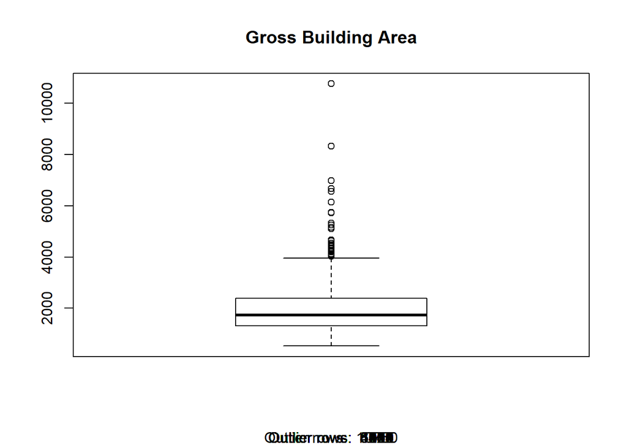

```r
boxplot(houses$GBA, main="Gross Building Area", sub=paste("Outlier rows: ", boxplot.stats(houses$GBA)$out))
```

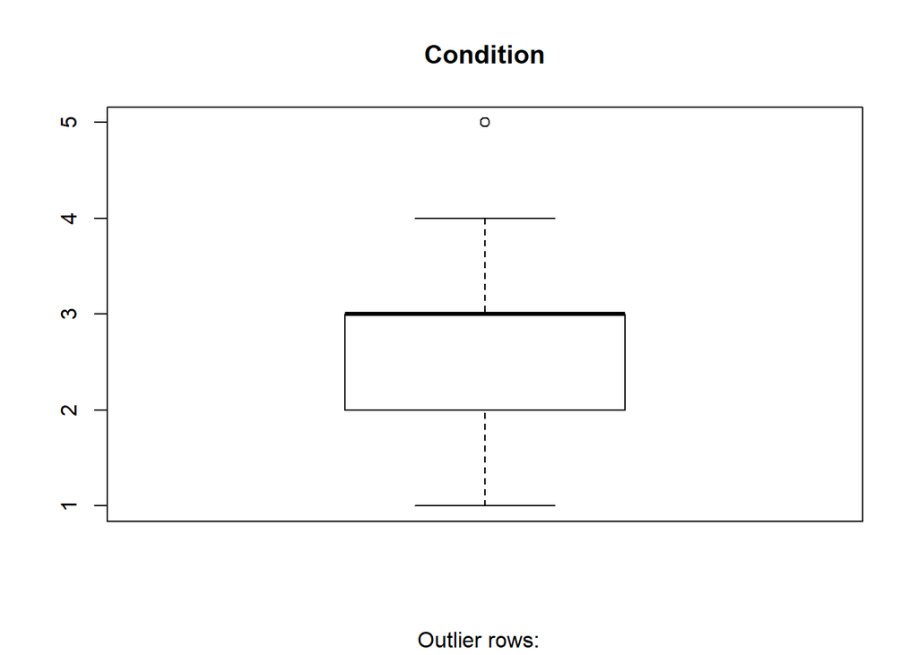

```r
boxplot(houses$CNDTN, main="Condition", sub=paste("Outlier rows: ", boxplot.stats(houses$CNDTN)$out))
```

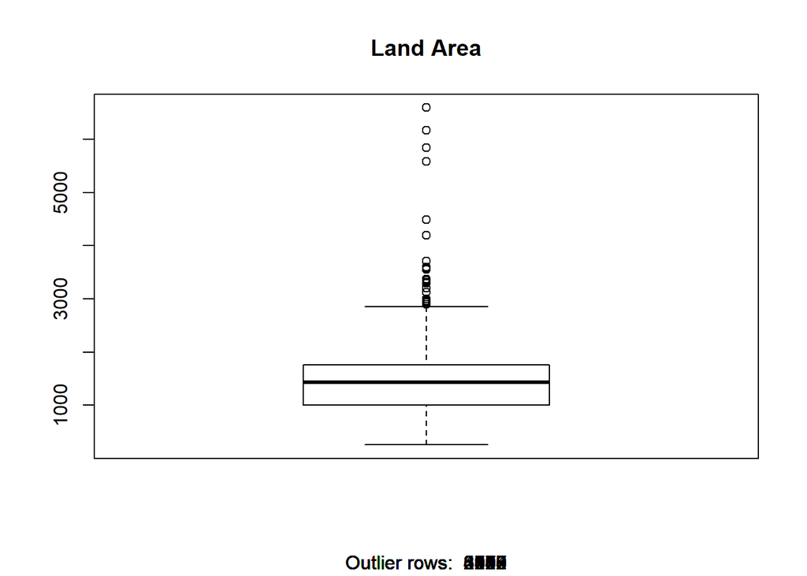

```r
boxplot(houses$LANDAREA, main="Land Area", sub=paste("Outlier rows: ", boxplot.stats(houses$LANDAREA)$out))
```

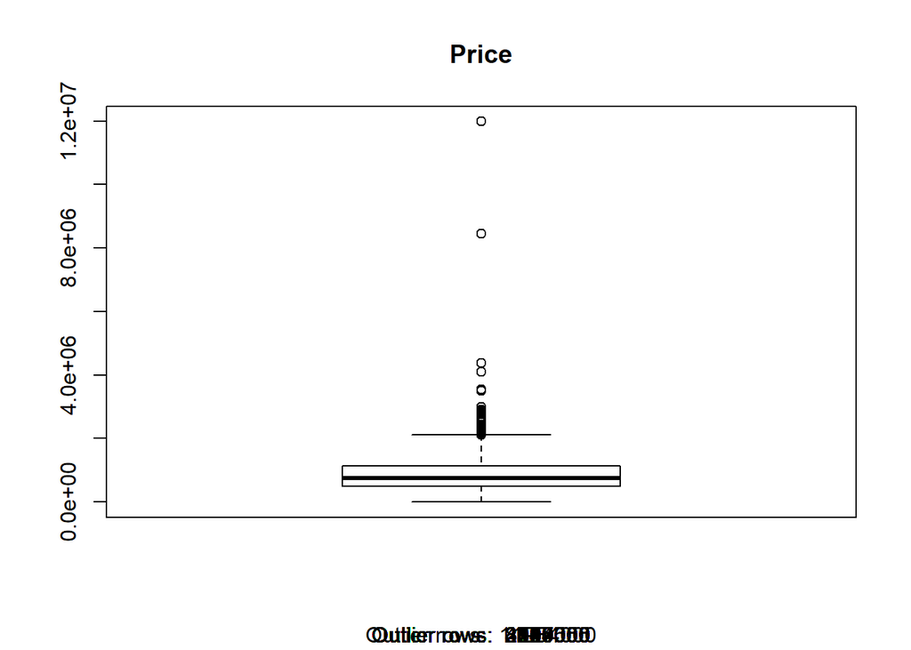

```r
boxplot(houses$PRICE, main="Price", sub=paste("Outlier rows: ", boxplot.stats(houses$PRICE)$out))
```

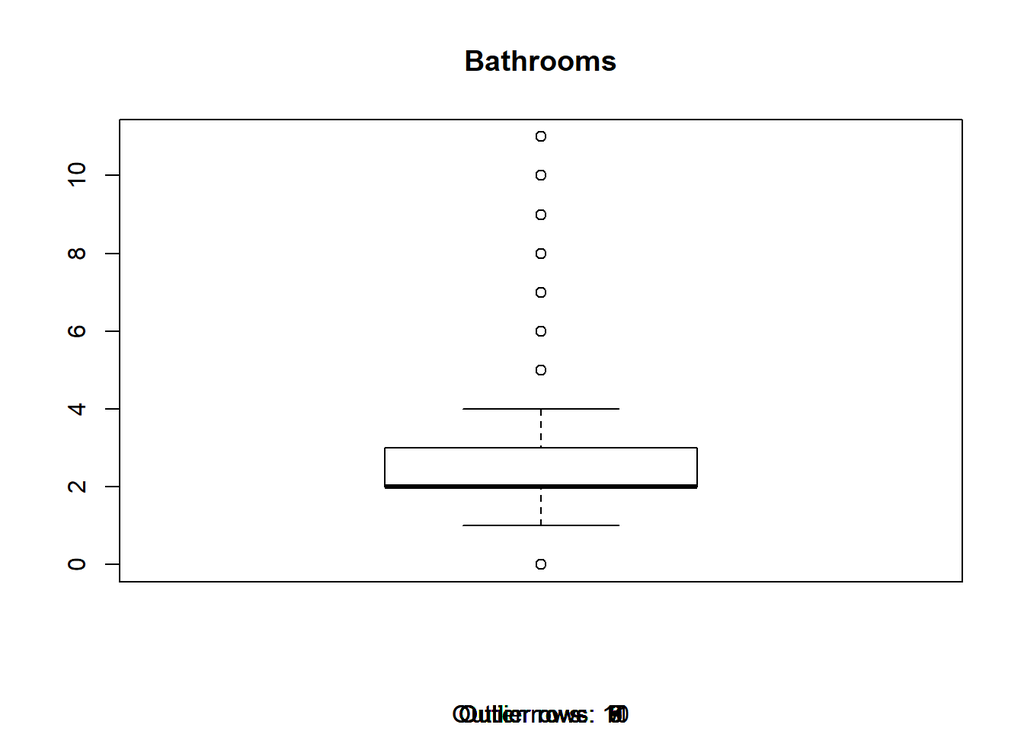

```r
# Boxplots to identify outliers

boxa <- boxplot(houses$BATHRM, main="Bathrooms", sub=paste("Outlier rows: ", boxplot.stats(houses$BATHRM)$out))
```

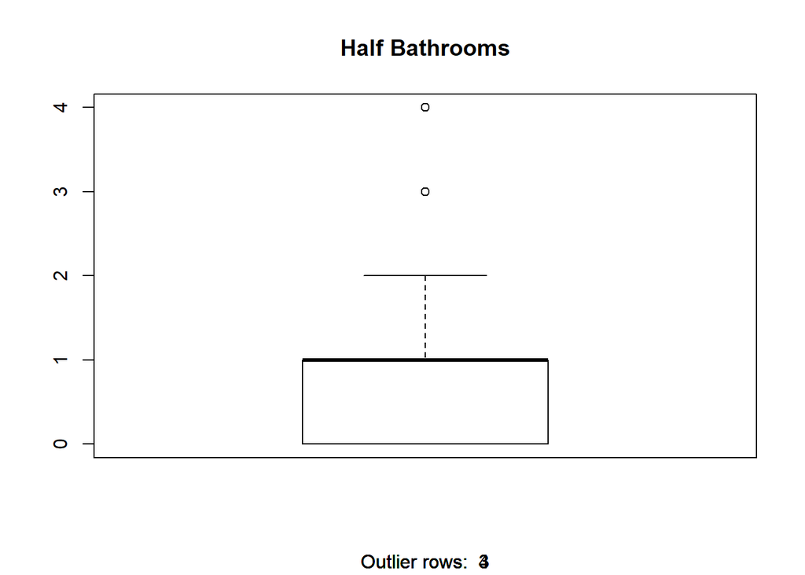

```r
boxb <- boxplot(houses$HF_BATHRM, main="Half Bathrooms", sub=paste("Outlier rows: ", boxplot.stats(houses$HF_BATHRM)$out))
```

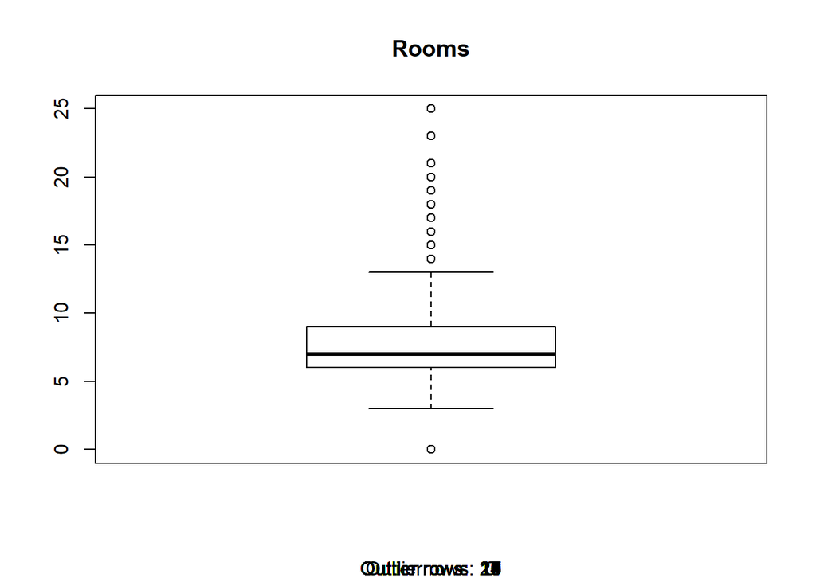

```r
boxc <- boxplot(houses$ROOMS, main="Rooms", sub=paste("Outlier rows: ", boxplot.stats(houses$ROOMS)$out))
```

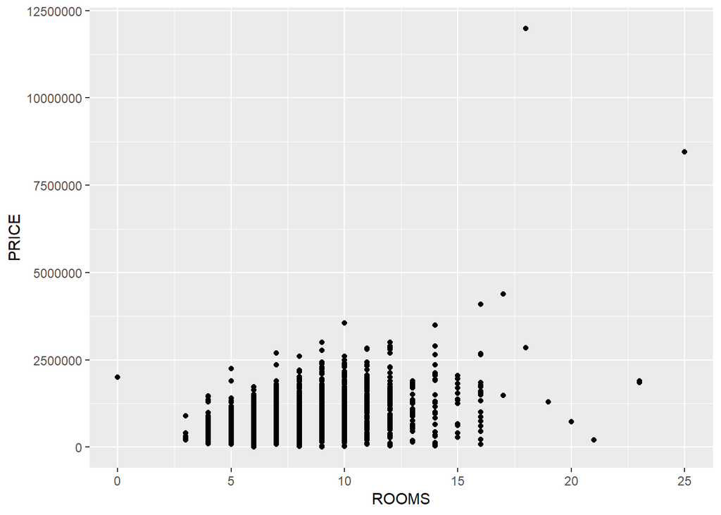

```r
# scatterplots
# price by room
room_price <- ggplot(houses, aes(x = ROOMS, y = PRICE))
room_price + geom_point()
```

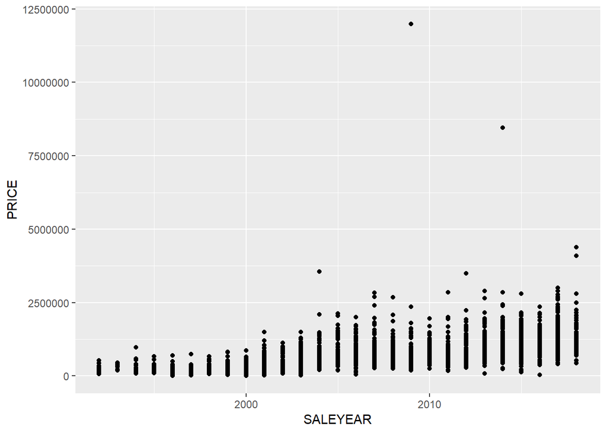

```r
# price by year
year_price <- ggplot(houses, aes(x = SALEYEAR, y = PRICE))
year_price + geom_point()
```